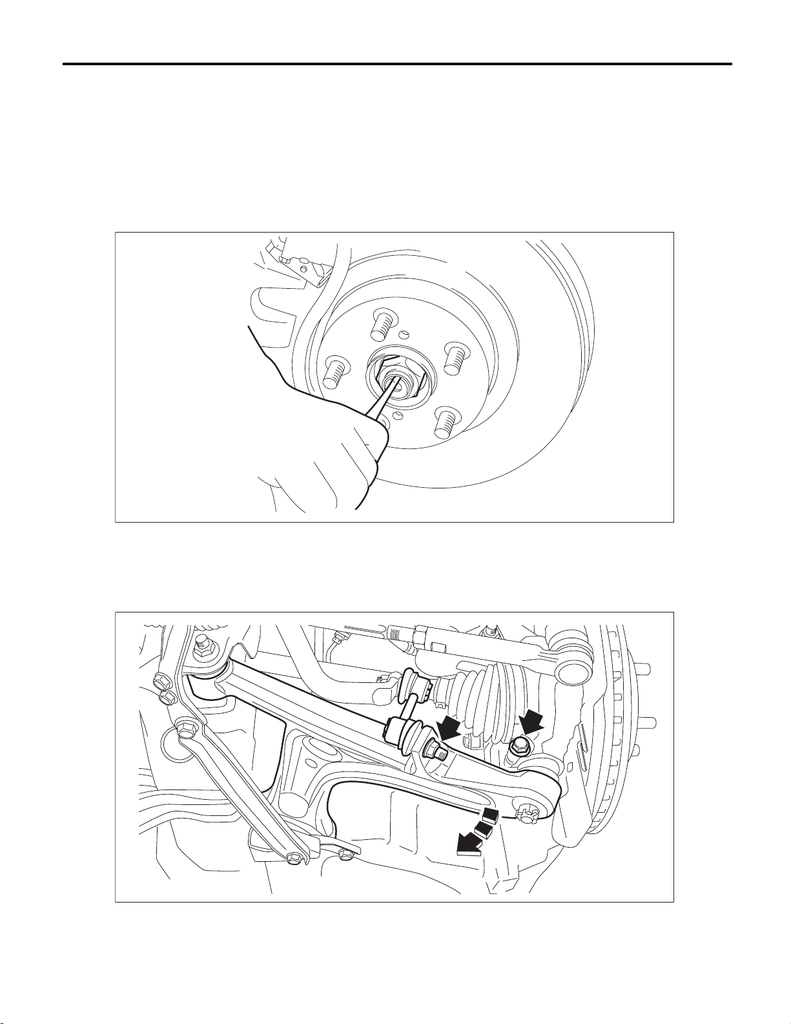

DS-48

Front Drive Shaft

DRIVE SHAFT SYSTEM

7. Front Drive Shaft

A: REMOVAL

1) Lift up the vehicle, and then remove the front wheels.

2) Remove the nut - axle.

CAUTION:

Do not loosen the nut - axle while the front axle is loaded. Doing so may damage the hub unit COMPL.

(1) Lift the crimped section of the nut - axle.

(2) Remove the nut - axle using a socket wrench while depressing the brake pedal.

3) Drain the transmission gear oil. (MT model)

4) Drain differential gear oil. (CVT model)

5) Disconnect the ball joint assembly.

(1) Remove the nut and disconnect the front stabilizer link.

(2) Remove the bolts, disconnect the front arm ball joint, and lower the front arm assembly.

DS-00486

DS-00582

15WRX_STI_US_EN.book 48 ページ ２０１５年２月１３日 金曜日 午前１１時２０分

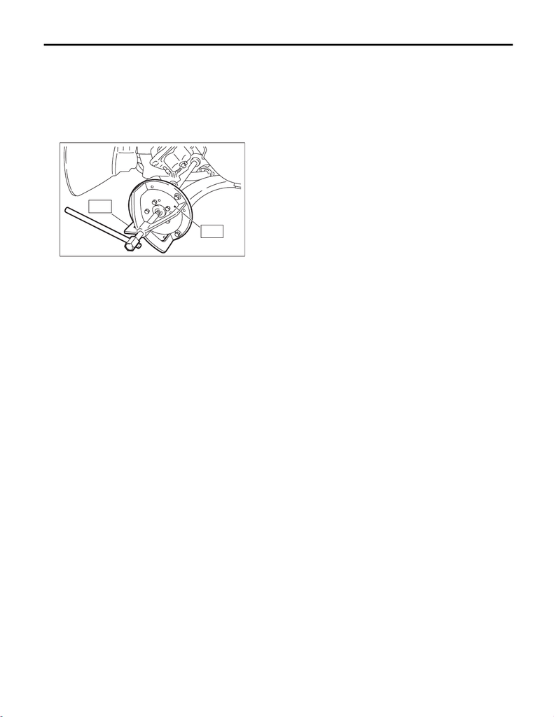

DS-49

Front Drive Shaft

DRIVE SHAFT SYSTEM

6) Remove the front drive shaft.

(1) Disconnect the housing assembly - front axle from the front drive shaft.

NOTE:

If it is hard to remove, use the ST.

Preparation tool:

ST1: AXLE SHAFT PULLER (926470000)

ST2: AXLE SHAFT PULLER PLATE (28099PA110)

(2) Using a tire lever, remove the front drive shaft from transmission.

CAUTION:

Be careful not to allow the tire lever to damage holder area.

Preparation tool:

Tire lever

B: INSTALLATION

1) Before installation, check the drive shaft assembly. <Ref. to DS-63, INSPECTION, Front Drive Shaft.>

2) Replace the differential side retainer oil seal with a new part.

• MT model: <Ref. to 6MT(TY85)-28, REPLACEMENT, Differential Side Retainer Oil Seal.>

• CVT model: <Ref. to CVT(TR690)-89, REPLACEMENT, Differential Side Retainer Oil Seal.>

CAUTION:

After pulling out the drive shaft assembly, be sure to replace with a new oil seal.

3) Insert the drive shaft assembly into the hub spline, and pull it into the specified position.

CAUTION:

Do not hammer the drive shaft assembly when installing.

4) Tighten the new nut - axle temporarily.

DS-00145

ST2

ST1

15WRX_STI_US_EN.book 49 ページ ２０１５年２月１３日 金曜日 午前１１時２０分

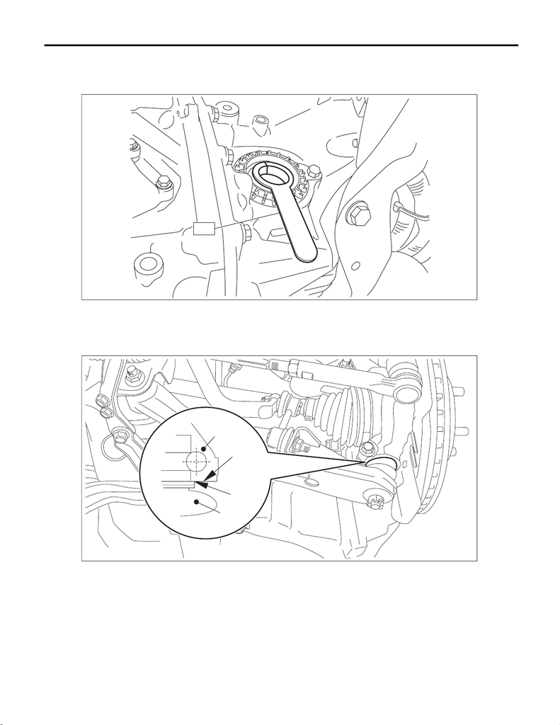

DS-50

Front Drive Shaft

DRIVE SHAFT SYSTEM

5) Using the ST, install the front drive shaft assembly to the transmission.

Preparation tool:

ST: OIL SEAL PROTECTOR (28399SA010)

6) Install the ball joint assembly to the housing assembly - front axle.

CAUTION:

Before tightening, make sure the bottom surface of the housing assembly - front axle and the

stepped section of ball joint are in contact.

Tightening torque:

50 N·m (5.1 kgf-m, 36.9 ft-lb)

(a) Bottom surface of housing ASSY -

front axle

(c) Housing ASSY - front axle (d) Ball joint

(b) Raised section of ball joint

AT-06601

ST

FS-00508

(a)

(b)

(c)

(d)

15WRX_STI_US_EN.book 50 ページ ２０１５年２月１３日 金曜日 午前１１時２０分

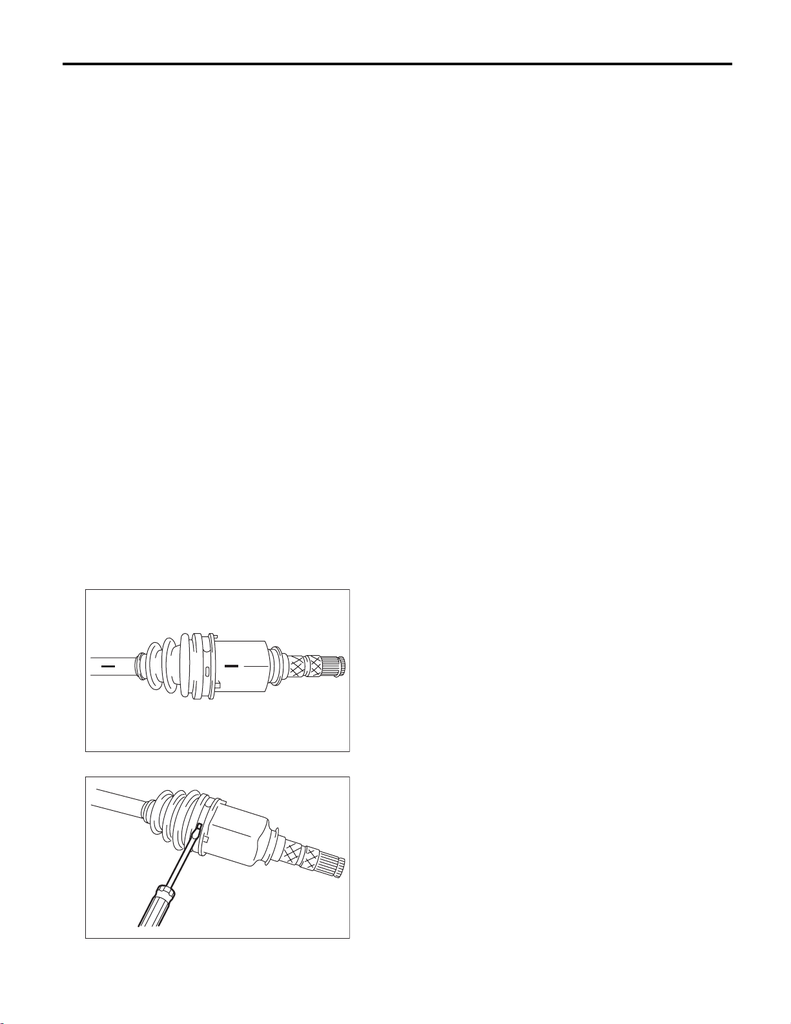

DS-51

Front Drive Shaft

DRIVE SHAFT SYSTEM

7) Install the stabilizer link.

Tightening torque:

60 N·m (6.1 kgf-m, 44.3 ft-lb)

8) While depressing the brake pedal, tighten new nuts - axle to the specified torque.

CAUTION:

Do not load the front axle before tightening the nut - axle. Doing so may damage the hub unit COMPL.

Tightening torque:

220 N·m (22.4 kgf-m, 162.3 ft-lb)

9) After tightening the nut - axle, lock it securely.

10) Fill transmission gear oil. (MT model)

11) Fill differential gear oil. (CVT model)

12) Install the front wheels.

Tightening torque:

120 N·m (12.2 kgf-m, 88.5 ft-lb)

13) Inspect the wheel alignment and adjust if necessary.

• Inspection: <Ref. to FS-10, INSPECTION, Wheel Alignment.>

• Adjustment: <Ref. to FS-15, ADJUSTMENT, Wheel Alignment.>

CAUTION:

When the wheel alignment has been adjusted, perform “VDC sensor midpoint setting mode”. <Ref.

to VDC-16, ADJUSTMENT, VDC Control Module and Hydraulic Control Unit (VDCCM&H/U).>

14) Perform reinitialization of the auto headlight beam leveler system. (Model with auto headlight beam lev-

eler) <Ref. to LI-16, PROCEDURE, Auto Headlight Beam Leveler System.>

C: DISASSEMBLY

1. AC + AAR TYPE

1) Remove the AAR outer race from shaft assembly.

CAUTION:

Be careful not to damage the boot.

(1) Place alignment marks on the shaft and outer race.

(2) Remove the AAR boot band and boot.

DS-00106

DS-00107

15WRX_STI_US_EN.book 51 ページ ２０１５年２月１３日 金曜日 午前１１時２０分

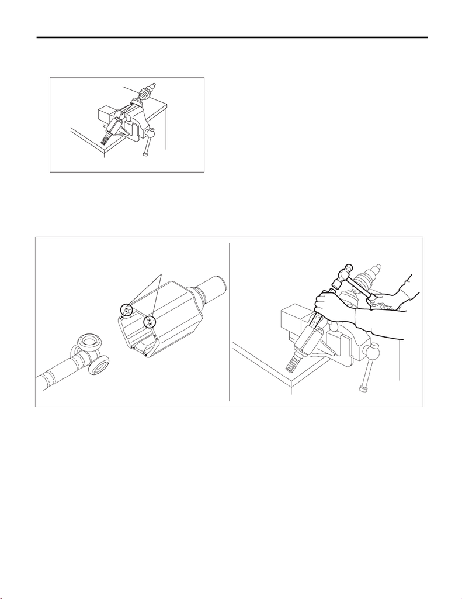

DS-52

Front Drive Shaft

DRIVE SHAFT SYSTEM

(3) Place the drive shaft between wooden blocks and fix it on a vise.

CAUTION:

Do not set the drive shaft directly on a vise.

(4) Tap the staking are of the outer race alternately with a plastic or wooden bar, and remove one roller

at a time.

CAUTION:

• Tap the staking area (A) of the outer race.

• Do not use a metal bar as the outer race may deform.

• Be careful not to damage the roller parts.

(5) Remove the outer race from shaft assembly.

CAUTION:

Make sure to have your associate hold the outer race when removing the third roller to prevent the

outer race from falling.

(6) Wipe off grease.

CAUTION:

The grease is a special type of grease. Do not mix with other grease.

DS-00417

DS-00507

(A)

15WRX_STI_US_EN.book 52 ページ ２０１５年２月１３日 金曜日 午前１１時２０分

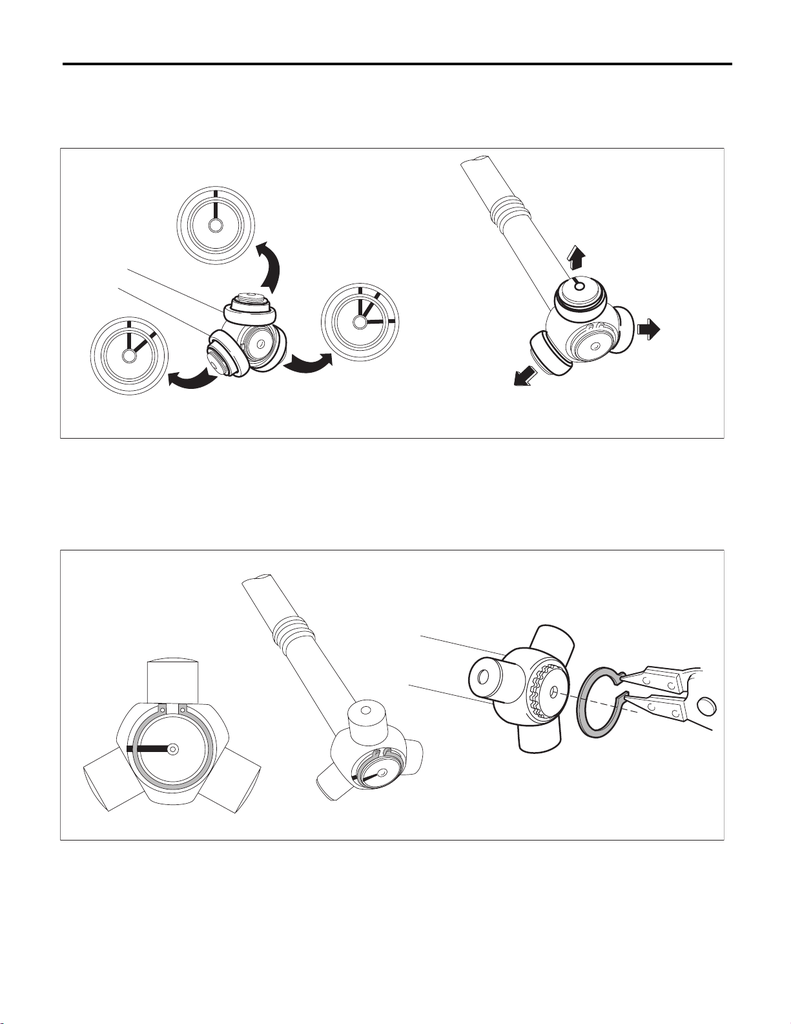

DS-53

Front Drive Shaft

DRIVE SHAFT SYSTEM

2) Remove the roller kit from trunnion.

CAUTION:

Be careful with the roller kit position.

(1) Place alignment marks on the roller kit and trunnion.

(2) Remove the roller kit from trunnion.

3) Remove the trunnion from the shaft.

(1) Place alignment marks on the trunnion and shaft.

(2) Remove the snap ring and trunnion.

CAUTION:

Be sure to wrap shaft splines with vinyl tape to protect the boot from scratches.

4) Remove the AAR boot.

NOTE:

The AC is a non-disassembly part, so the drive shaft disassembly stops here.

DS-00502

DS-00503

15WRX_STI_US_EN.book 53 ページ ２０１５年２月１３日 金曜日 午前１１時２０分

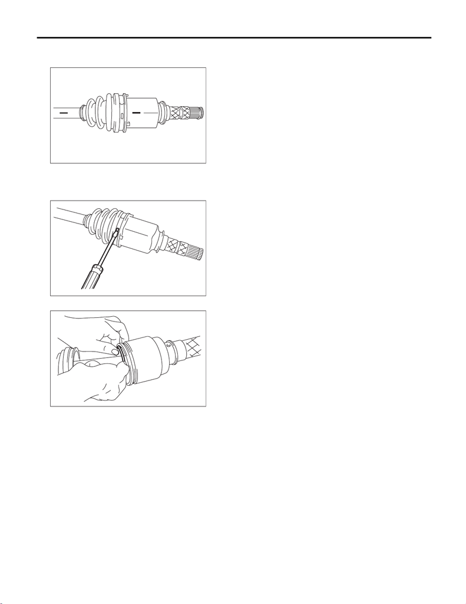

DS-54

Front Drive Shaft

DRIVE SHAFT SYSTEM

2. EBJ + PTJ TYPE

1) Place alignment marks on the shaft and outer race.

2) Remove the PTJ boot band and boot.

CAUTION:

Be careful not to damage the boot.

3) Remove the snap ring from PTJ outer race.

4) Remove the PTJ outer race from shaft assembly.

5) Wipe off grease.

CAUTION:

The grease is a special type of grease. Do not mix with other grease.

DS-00106

DS-00107

DS-00108

15WRX_STI_US_EN.book 54 ページ ２０１５年２月１３日 金曜日 午前１１時２０分

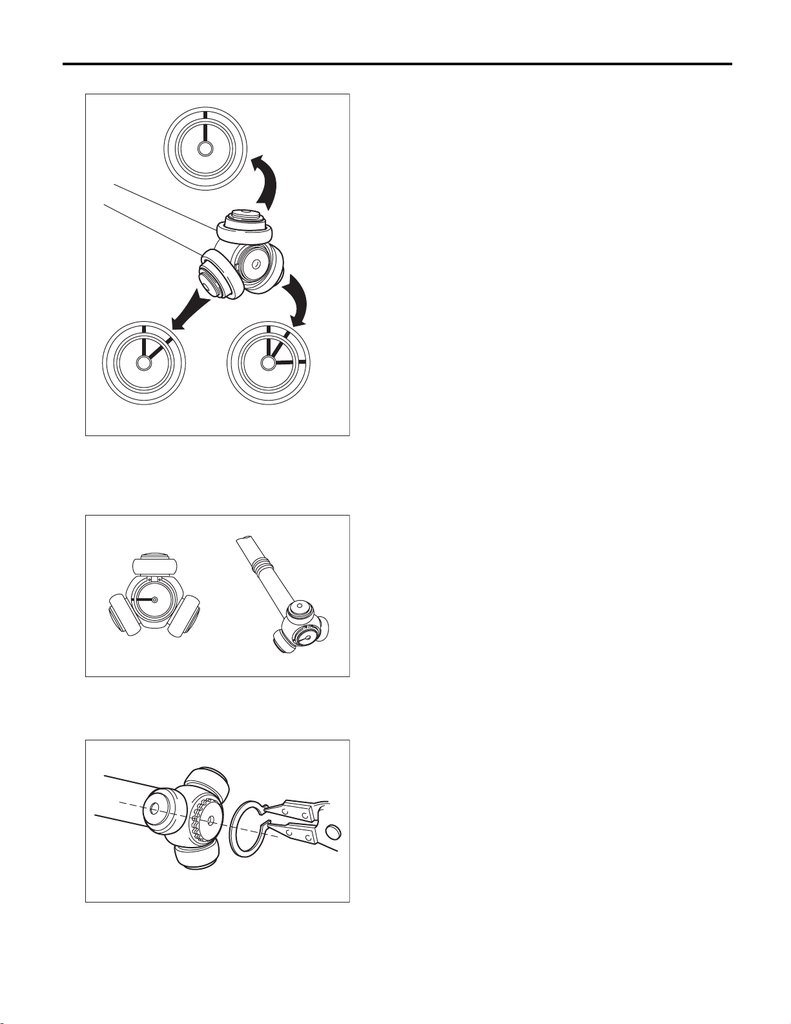

DS-55

Front Drive Shaft

DRIVE SHAFT SYSTEM

6) Place alignment marks on the roller kit and trunnion.

7) Remove the roller kit from trunnion.

CAUTION:

Be careful with the roller kit position.

8) Place alignment marks on the trunnion and shaft.

9) Remove the snap ring and trunnion.

CAUTION:

Be sure to wrap shaft splines with vinyl tape to protect the boot from scratches.

DS-00109

DS-00110

DS-00111

15WRX_STI_US_EN.book 55 ページ ２０１５年２月１３日 金曜日 午前１１時２０分

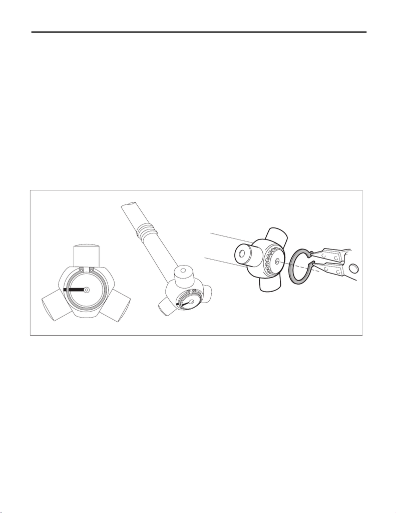

DS-56

Front Drive Shaft

DRIVE SHAFT SYSTEM

10) Remove the PTJ boot.

11) Remove the O-ring from the groove of the shaft.

NOTE:

The EBJ is a non-disassembly part, so the axle disassembly stops here.

D: ASSEMBLY

1. AC + AAR TYPE

NOTE:

Use specified grease.

AAR side:

One-Luber C

1) Pass the AAR boot through the shaft.

2) Install the trunnion to the shaft.

(1) Match the alignment marks, and attach the trunnion onto the shaft.

(2) Attach the snap ring to the shaft.

CAUTION:

Confirm that the snap ring is completely fitted in the shaft groove.

3) Fill 50 to 60 g (1.76 to 2.12 oz) of specified grease into the interior of AAR outer race.

4) Install the trunnion to the roller kit.

(1) Apply a thin coat of specified grease to the roller kit and trunnion.

(2) Place the drive shaft between wooden blocks and fix it on a vise.

CAUTION:

Do not set the drive shaft directly on a vise.

5) Align the alignment marks on the shaft and outer race.

DS-00503

15WRX_STI_US_EN.book 56 ページ ２０１５年２月１３日 金曜日 午前１１時２０分

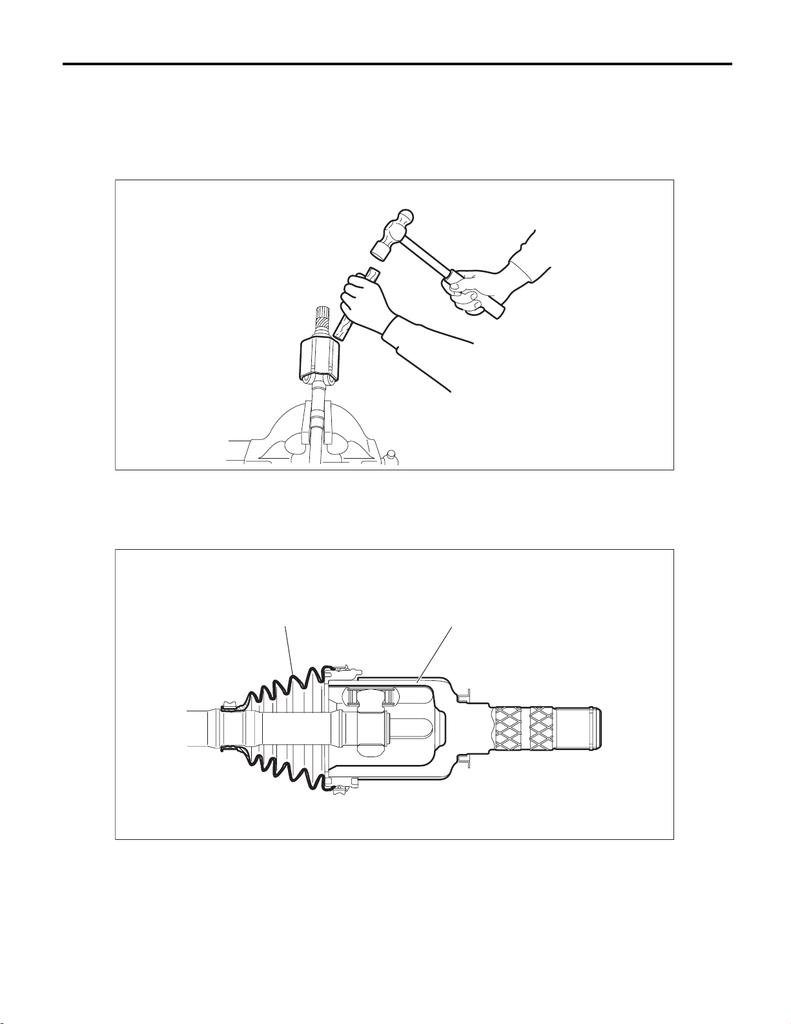

DS-57

Front Drive Shaft

DRIVE SHAFT SYSTEM

6) Tap the insertion upper part of the outer race alternately using a plastic or wood bar shown in the figure,

and then insert the roller one by one.

CAUTION:

• Do not use a metal bar as the outer race may deform.

• Do not tap on the end of outer race (shaft part).

• Be careful not to deform the baffle plate.

7) Apply an even coat of the specified grease 30 to 40 g (1.06 to 1.41 oz) to the entire inner surface of boot.

8) Install the AAR boot taking care not to twist it.

CAUTION:

Do not let grease get on groove of the outer race side.

(a) Outer race (b) Boot

DS-00622

DS-00621

(b)

(a)

15WRX_STI_US_EN.book 57 ページ ２０１５年２月１３日 金曜日 午前１１時２０分

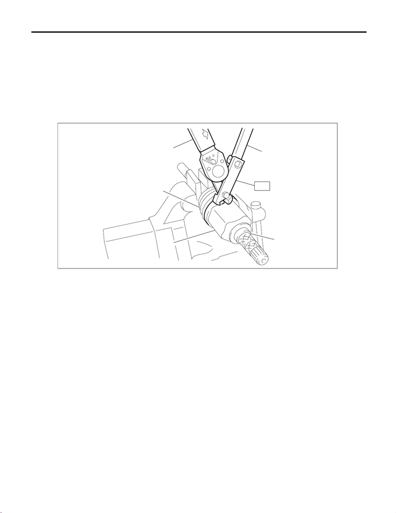

DS-58

Front Drive Shaft

DRIVE SHAFT SYSTEM

9) Insert a flat tip screwdriver, etc. between outer race and boot to make pressure inside of boot as high as

barometric pressure.

10) Tighten the boot band.

(1) Install the new large boot band and small boot band at the required positions.

(2) Connect the torque wrench and socket flex handle to the ST.

Preparation tool:

ST: BOOT BAND PLIERS (28099AC000)

Torque wrench

Socket flex handle

(3) Use a prepared tool, tighten the boot band.

Clearance at the crimped section of the boot band:

Large boot band: 1 mm (0.04 in) or less

Small boot band: 1 mm (0.04 in) or less

Tightening torque:

Large boot band: 178 N·m (18.1 kgf-m, 131.3 ft-lb)

Small boot band: 145 N·m (14.8 kgf-m, 106.9 ft-lb)

11) Extend and retract the AAR repeatedly to provide an equal coating of grease.

(A) Large boot band (C) Torque wrench (E) Outer race

(B) Boot (D) Socket flex handle

DS-00505

ST

(A)

(B)

(C)

(D)

(E)

ONLY

15WRX_STI_US_EN.book 58 ページ ２０１５年２月１３日 金曜日 午前１１時２０分

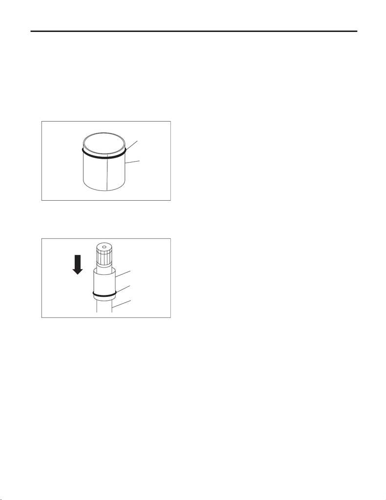

DS-59

Front Drive Shaft

DRIVE SHAFT SYSTEM

2. EBJ + PTJ TYPE

1) Roll up a thick piece of paper to a size where the shaft can pass through, and affix with tape to form a cyl-

inder.

2) Attach a new O-ring on this cylinder.

CAUTION:

• Always use a new O-ring.

• Be careful that the O-ring does not become scratched and that there are no foreign objects at-

tached to it.

• Make sure to install the O-ring so that it does not twist as much as possible.

• Do not stretch the O-ring to 30 mm (1.18 in) inner diameter or more.

3) Pass the cylinder material onto the shaft, and slide in the direction of the shaft axis.

4) Clean the shaft boot groove, and wipe off the grease.

DS-00451

(1)

(2)

(1) O-ring

(2) Cylinder made with thick paper, etc.

DS-00452

(1)

(2)

(3)

(1) Cylinder material

(2) O-ring

(3) Shaft

15WRX_STI_US_EN.book 59 ページ ２０１５年２月１３日 金曜日 午前１１時２０分

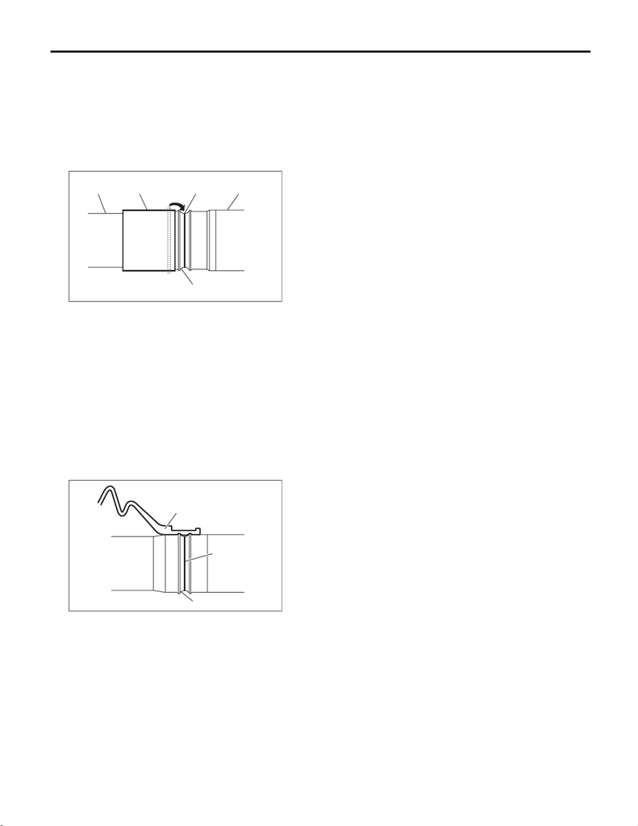

DS-60

Front Drive Shaft

DRIVE SHAFT SYSTEM

5) Slide the cylinder material near the shaft boot groove, and move the O-ring from the cylinder material onto

the shaft boot groove.

CAUTION:

• Attach the O-ring to the shaft boot groove center.

• Be careful that the O-ring does not become scratched and that there are no foreign objects at-

tached to it.

• Make sure to install the O-ring so that it does not twist as much as possible.

• With the O-ring attached, do not wash with kerosene, gasoline, etc.

6) Pass the PTJ small diameter boot band through the shaft.

7) Wrap vinyl tape around the splines of the shaft.

CAUTION:

To prevent damage to the boots, make sure to always wrap with vinyl tape for protection.

8) Install a new PTJ boot.

CAUTION:

Make sure to fit securely on the boot groove of the shaft.

(1) (2) (3) (1)

(4)

DS-00453

(1) Shaft

(2) Cylinder material

(3) O-ring

(4) Boot groove

(1)

(3)

(2)

DS-00454

(1) PTJ boot

(2) O-ring

(3) Boot groove

15WRX_STI_US_EN.book 60 ページ ２０１５年２月１３日 金曜日 午前１１時２０分

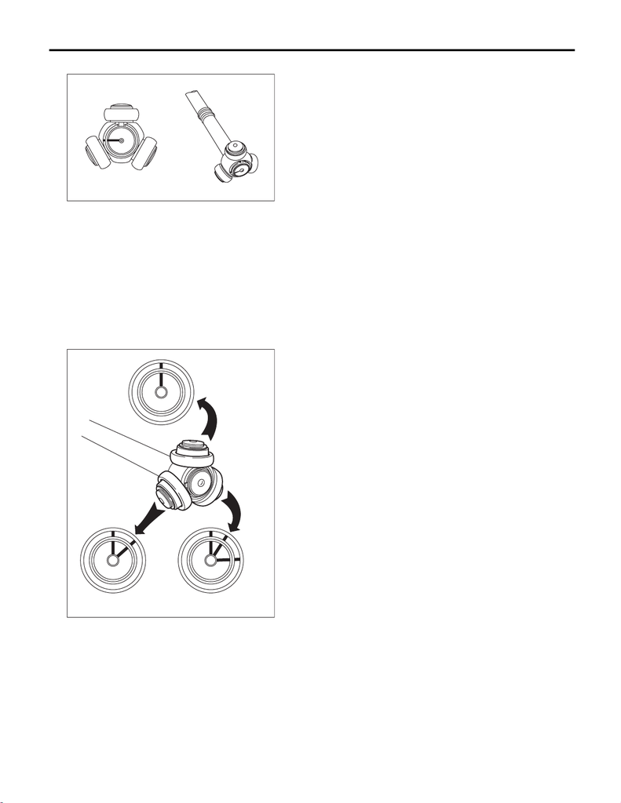

DS-61

Front Drive Shaft

DRIVE SHAFT SYSTEM

9) Match the alignment marks, and attach the trunnion onto the shaft.

10) Attach the snap ring to the shaft.

CAUTION:

Confirm that the snap ring is completely fitted in the shaft groove.

11) Fill 100 to 110 g (3.53 to 3.88 oz) of specified grease into the interior of the PTJ outer race.

Grease:

NKG302

12) Apply a thin coat of specified grease to the roller kit and trunnion.

13) Match the alignment marks of the roller kit and trunnion, and attach the roller kit.

CAUTION:

Be careful with the roller kit position.

DS-00110

DS-00109

15WRX_STI_US_EN.book 61 ページ ２０１５年２月１３日 金曜日 午前１１時２０分

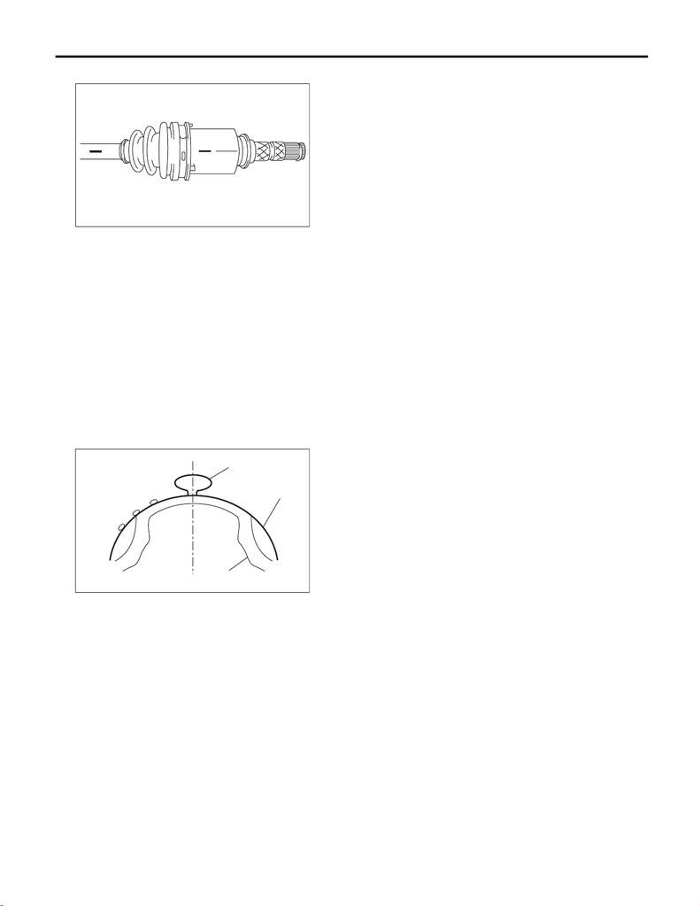

DS-62

Front Drive Shaft

DRIVE SHAFT SYSTEM

14) Match the alignment marks of the shaft and outer race, and attach the outer race.

15) Install the snap ring in the groove of the PTJ outer race.

CAUTION:

Pull the shaft lightly and make sure that the snap ring is completely fitted in the groove.

16) Apply an even coat of the specified grease 30 to 40 g (1.06 to 1.41 oz) to the entire inner surface of boot.

17) Attach the PTJ boot taking care not to twist it.

CAUTION:

• Clean the large end of PTJ boot and the boot groove well, and remove the grease and other sub-

stances.

• When installing the PTJ boot, position the outer race of the PTJ at center of the stroke.

18) Set the new boot band at the specified position.

19) Tighten the boot bands using ST, torque wrench and socket flex handle.

CAUTION:

The large boot band is to be tightened so that the omega shaped part is at the position indicated in

the figure below.

DS-00106

DS-00456

(1)

(2)

(3)

(1) Omega shaped part

(2) Boot band

(3) Outer race

15WRX_STI_US_EN.book 62 ページ ２０１５年２月１３日 金曜日 午前１１時２０分

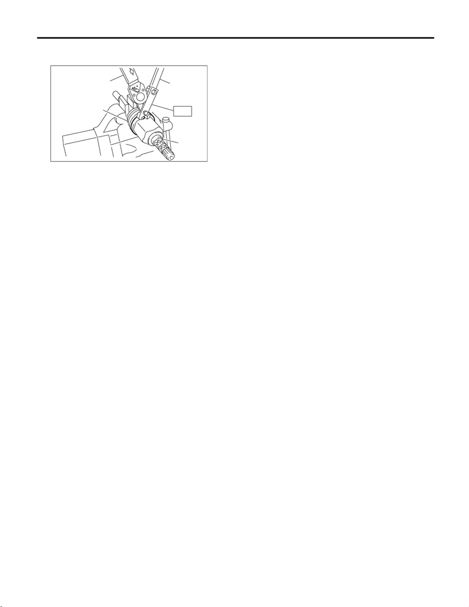

DS-63

Front Drive Shaft

DRIVE SHAFT SYSTEM

Preparation tool:

ST: BOOT BAND PLIERS (28099AC000)

Tightening torque:

Large boot band: 178 N·m (18.1 kgf-m, 131.3 ft-lb)

Small boot band: 145 N·m (14.8 kgf-m, 106.9 ft-lb)

20) Extend and retract the PTJ repeatedly so that grease is spread evenly.

E: INSPECTION

Check the removed parts for damage, wear, corrosion etc. If faulty, repair or replace.

• AAR and AC:

Check for seizure, corrosion, damage, wear and excessive play.

• PTJ (Pillow Tripod Joint)

Check for seizure, corrosion, damage, wear and excessive play.

• EBJ (High-Efficiency Compact Ball fixed Joint)

Check for seizure, corrosion, damage and excessive play.

• Shaft:

Check for excessive bending, twisting, damage and wear.

• Boot:

Check for wear, warping, breakage and scratches.

• Grease:

Check for discoloration and fluidity.

DS-00120

ST

(A)

(B)

(C)

(D)

(E)

ONLY

(A) Large boot band

(B) Boot

(C) Torque wrench

(D) Socket flex handle

(E) Outer race

15WRX_STI_US_EN.book 63 ページ ２０１５年２月１３日 金曜日 午前１１時２０分